```python
import io
from IPython.nbformat import current

with io.open('/Users/kgkolias/Desktop/Airbnb Coursework/PDS_Airbnb.ipynb', 'r', encoding='utf-8') as f:
    nb = current.read(f, 'json')

word_count = 0
for cell in nb.worksheets[0].cells:
    if cell.cell_type == "markdown":
        word_count += len(cell['source'].replace('#', '').lstrip().split(' '))
print(word_count)
```

```
1496
```

# 1. Initial Steps

### 1.1 Import Libraries

```python
import pandas as pd
from pandas import Series
import os
import re
import numpy as np
import seaborn as sns
sns.set(style="ticks")
import csv as csv
import datetime as dt
from collections import Counter
from collections import defaultdict
import seaborn as sbs

import matplotlib
import matplotlib.pyplot as plt
matplotlib.style.use('ggplot')
%matplotlib inline

import statsmodels.api as sm
import seaborn as sns
import scipy.stats as stats
from scipy.stats import kurtosis, skew


from sklearn import linear_model
from sklearn.preprocessing import Imputer
from sklearn.preprocessing import StandardScaler
from sklearn.ensemble import RandomForestRegressor
from sklearn.model_selection import cross_val_score, train_test_split, GridSearchCV
from sklearn.metrics import mean_squared_error, r2_score

from sklearn.model_selection import train_test_split

from sklearn.preprocessing import scale
from scipy.spatial.distance import cdist

#Lasso Feature Selection
from sklearn.linear_model import RidgeCV, LassoCV, Ridge, Lasso
from sklearn import linear_model, datasets

#Multiple Linear Regression
from sklearn.model_selection import train_test_split
from sklearn.metrics import mean_squared_error
from sklearn.linear_model import LinearRegression


#Random Forest
from sklearn.model_selection import cross_val_score
from sklearn.model_selection import GridSearchCV
from sklearn.ensemble import RandomForestRegressor


#MinMaxScaler
from sklearn.preprocessing import MinMaxScaler

import plotly.graph_objects as go


seed=69
np.random.seed(seed)
pd.options.display.max_columns = 10

#altair library
import altair as alt


import warnings
warnings.filterwarnings('ignore')
```

### 1.2 Data Importing and assign them into DataFrames

```python
listingsDF = pd.read_csv('listings.csv',low_memory=False)
reviewsDF =  pd.read_csv('reviews.csv',low_memory=False)
```

```python
print ("There are " + str(listingsDF.shape[0]) + " listed London properties in the dataset and " + str(listingsDF.shape[1]) +" column variables." + "\n" + "Here is one example row transposed.")
sample = pd.DataFrame(listingsDF.iloc[0].T)
sample['Col_Type'] = pd.DataFrame(listingsDF.dtypes.astype(str))
pd.set_option('display.max_colwidth', 35)
print (sample)
```

```
There are 85273 listed London properties in the dataset and 106 column variables.
Here is one example row transposed.
                                                                      0  \
id                                                                11551
listing_url                          https://www.airbnb.com/rooms/11551
scrape_id                                                20190914144451
last_scraped                                                 2019-09-15
name                                 Arty and Bright London Apartmen...
...                                                                 ...
calculated_host_listings_count                                        2
calculated_host_listings_count_e...                                   2
calculated_host_listings_count_p...                                   0
calculated_host_listings_count_s...                                   0
reviews_per_month                                                  1.59

                                    Col_Type
id                                     int64
listing_url                           object
scrape_id                              int64
last_scraped                          object
name                                  object
...                                      ...
calculated_host_listings_count         int64
calculated_host_listings_count_e...    int64
calculated_host_listings_count_p...    int64
calculated_host_listings_count_s...    int64
reviews_per_month                    float64

[106 rows x 2 columns]
```

```python
#Review dataset is straightforward linking id,date, guest detail and text comments for possible mining
print ("There are " + str(reviewsDF.shape[0]) + " individual review rows in the dataset. This is for " + str(reviewsDF['listing_id'].nunique())  + " properties."+ "\n" + "There are " + str(reviewsDF.shape[1]) +" columns, but the main item is the text comments with various identifiers.")
reviewsDF.head()
```

```
There are 1434052 individual review rows in the dataset. This is for 64270 properties.
There are 6 columns, but the main item is the text comments with various identifiers.
```

|  | listing_id | id | date | reviewer_id | reviewer_name | comments |
| --- | --- | --- | --- | --- | --- | --- |
| 0 | 11551 | 30672 | 2010-03-21 | 93896 | Shar-Lyn | The flat was bright, comfortabl... |
| 1 | 11551 | 32236 | 2010-03-29 | 97890 | Zane | We stayed with Adriano and Vale... |
| 2 | 11551 | 41044 | 2010-05-09 | 104133 | Chase | Adriano was a fantastic host. W... |
| 3 | 11551 | 48926 | 2010-06-01 | 122714 | John & Sylvia | We had a most wonderful stay wi... |
| 4 | 11551 | 58352 | 2010-06-28 | 111543 | Monique | I'm not sure which of us misu... |

### 1.3 Initial size reduction of the listings dataset to 1/2

```python
new_rows_size = round(listingsDF.shape[0] / 2)

listingsDF = listingsDF.drop(listingsDF.index[new_rows_size:85274])
listingsDF.shape
```

```
(42636, 106)
```

Reducing the samples of the dataset for time optimization purposes in the Machine Learning Modelling Stage.

# 2. Data Cleansing and pre-processing

#### 2.1.1 Initially drop the columns that are not used in the project

```python
columns_to_be_dropped = ['listing_url','scrape_id', 'last_scraped', 'name', 'summary', 'host_url',
                         'thumbnail_url','medium_url', 'picture_url', 'xl_picture_url', 'host_acceptance_rate',
                         'host_thumbnail_url', 'host_neighbourhood', 'host_picture_url', 'neighbourhood_group_cleansed',
                         'market','transit', 'bed_type', 'space', 'description','house_rules', 'minimum_minimum_nights',
                         'maximum_minimum_nights', 'minimum_maximum_nights', 'maximum_maximum_nights','license',
                         'jurisdiction_names', 'zipcode', 'host_name', 'host_location', 'state', 'number_of_reviews_ltm',
                        'street', 'city', 'smart_location', 'country_code', 'availability_60', 'availability_90', 'calendar_last_scraped']
listingsDF.drop(columns_to_be_dropped, inplace=True, axis=1)
```

```python
# Check null Values
listingsDF.isna().sum()
```

```
id                                                  0
experiences_offered                                 0
neighborhood_overview                           15237
notes                                           24375
access                                          16040
                                                ...
calculated_host_listings_count                      0
calculated_host_listings_count_entire_homes         0
calculated_host_listings_count_private_rooms        0
calculated_host_listings_count_shared_rooms         0
reviews_per_month                                8427
Length: 67, dtype: int64
```

#### 2.1.2 Remove duplicates

```python
listingsDF.drop_duplicates(subset=None, keep='first', inplace=False)
```

|  | id | experiences_offered | neighborhood_overview | notes | access | ... | calculated_host_listings_count | calculated_host_listings_count_entire_homes | calculated_host_listings_count_private_rooms | calculated_host_listings_count_shared_rooms | reviews_per_month |
| --- | --- | --- | --- | --- | --- | --- | --- | --- | --- | --- | --- |
| 0 | 11551 | family | Not even 10 minutes by metro fr... | No Smoking (very strict) Check-... | Guest will have access to the e... | ... | 2 | 2 | 0 | 0 | 1.59 |
| 1 | 13913 | business | Finsbury Park is a friendly mel... | For art lovers I can give guest... | Guest will have access to the s... | ... | 3 | 1 | 2 | 0 | 0.14 |
| 2 | 15400 | romantic | It is Chelsea. | The building next door is in th... | There are two wardrobes for gue... | ... | 1 | 1 | 0 | 0 | 0.73 |
| 3 | 17402 | none | Location, location, location! Y... | This property has new flooring ... | Full use of whole independent a... | ... | 15 | 15 | 0 | 0 | 0.40 |
| 4 | 24328 | family | - Battersea is a quiet family a... | - Please have a profile or tell... | - there is a communal garden in... | ... | 1 | 1 | 0 | 0 | 0.86 |
| ... | ... | ... | ... | ... | ... | ... | ... | ... | ... | ... | ... |
| 42631 | 22997551 | none | "It has an incredible history, ... | NaN | NaN | ... | 1 | 0 | 1 | 0 | 0.21 |
| 42632 | 22997553 | none | NaN | NaN | NaN | ... | 68 | 68 | 0 | 0 | NaN |
| 42633 | 22997609 | none | NaN | NaN | NaN | ... | 68 | 68 | 0 | 0 | NaN |
| 42634 | 22998262 | none | NaN | NaN | NaN | ... | 1 | 0 | 1 | 0 | 0.17 |
| 42635 | 22998636 | none | NaN | NaN | NaN | ... | 1 | 1 | 0 | 0 | 0.15 |

42636 rows × 67 columns

#### 2.1.3 Change boolean-valued columns from 't'/'f', to numerical 1/0

```python
boolean_columns = ['host_is_superhost', 'host_has_profile_pic', 'host_identity_verified', 'is_location_exact', 'has_availability', 'requires_license', 'instant_bookable', 'is_business_travel_ready', 'require_guest_profile_picture', 'require_guest_phone_verification']
listingsDF['host_is_superhost'] = listingsDF['host_is_superhost'].replace('t',1).replace('f',0)
listingsDF['host_has_profile_pic'] = listingsDF['host_has_profile_pic'].replace('t',1).replace('f',0)
listingsDF['host_identity_verified'] = listingsDF['host_identity_verified'].replace('t',1).replace('f',0)
listingsDF['is_location_exact'] = listingsDF['is_location_exact'].replace('t',1).replace('f',0)
listingsDF['has_availability'] = listingsDF['has_availability'].replace('t',1).replace('f',0)
listingsDF['requires_license'] = listingsDF['requires_license'].replace('t',1).replace('f',0)
listingsDF['instant_bookable'] = listingsDF['instant_bookable'].replace('t',1).replace('f',0)
listingsDF['is_business_travel_ready'] = listingsDF['is_business_travel_ready'].replace('t',1).replace('f',0)
listingsDF['require_guest_profile_picture'] = listingsDF['require_guest_profile_picture'].replace('t',1).replace('f',0)
listingsDF['require_guest_phone_verification'] = listingsDF['require_guest_phone_verification'].replace('t',1).replace('f',0)
```

#### 2.1.4 Plot the distribution of the numerical, boolean attributes

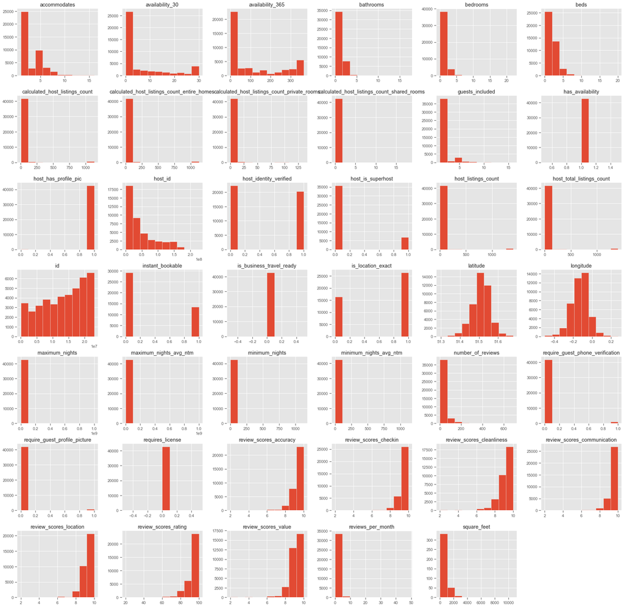

```python
# Distribution of numerical and boolean attributes
listingsDF.hist(figsize=(30,30));
```

From the Histograms above we understand that the attributes with only one column can be dropped.

```python
listingsDF.drop(['host_has_profile_pic', 'has_availability', 'is_business_travel_ready','maximum_nights_avg_ntm',
                 'minimum_nights_avg_ntm', 'require_guest_profile_picture', 'requires_license'], axis=1, inplace=True)
```

#### 2.1.4 Remove the '$' and / or ',' symbols from the values of certain numerical columns

```python
listingsDF['price'] = listingsDF['price'].str.replace('$', '').str.replace(',', '')
listingsDF['weekly_price'] = listingsDF['weekly_price'].str.replace('$', '').str.replace(',', '')
listingsDF['monthly_price'] = listingsDF['monthly_price'].str.replace('$', '').str.replace(',', '')
listingsDF['security_deposit'] = listingsDF['security_deposit'].str.replace('$', '').str.replace(',', '')
listingsDF['cleaning_fee'] = listingsDF['cleaning_fee'].str.replace('$', '').str.replace(',', '')
listingsDF['extra_people'] = listingsDF['extra_people'].str.replace('$', '').str.replace(',', '')
listingsDF['host_response_rate'] = listingsDF['host_response_rate'].str.replace('%', '')
```

#### 2.1.5 Change the columns types from string to numerical in certain columns

```python
listingsDF['price'] = pd.to_numeric(listingsDF['price'], errors='coerce').fillna(listingsDF['price'].median(), downcast='infer')
listingsDF['weekly_price'] = pd.to_numeric(listingsDF['weekly_price'], errors='coerce').fillna(listingsDF['weekly_price'].median(), downcast='infer')
listingsDF['monthly_price'] = pd.to_numeric(listingsDF['monthly_price'], errors='coerce').fillna(listingsDF['monthly_price'].median(), downcast='infer')
listingsDF['security_deposit'] = pd.to_numeric(listingsDF['security_deposit'], errors='coerce').fillna(0, downcast='infer')
listingsDF['cleaning_fee'] = pd.to_numeric(listingsDF['cleaning_fee'], errors='coerce').fillna(0, downcast='infer')
listingsDF['extra_people'] = pd.to_numeric(listingsDF['extra_people'], errors='coerce').fillna(0, downcast='infer')
listingsDF['host_response_rate'] = pd.to_numeric(listingsDF['host_response_rate'], errors='coerce')
```

#### 2.1.7 'experiences_offered' column

```python
listingsDF.experiences_offered.value_counts()
```

```
none        40903
business      598
family        493
social        426
romantic      216
Name: experiences_offered, dtype: int64
```

The column 'experiences_offered' has a null value most of the times, so it can be dropped from the dataframe.

```python
listingsDF.drop('experiences_offered', axis=1, inplace=True)
```

#### 2.1.8 Convert string columns to datetime

```python
listingsDF.host_since = pd.to_datetime(listingsDF.host_since)
listingsDF.first_review = pd.to_datetime(listingsDF.first_review)
listingsDF.last_review = pd.to_datetime(listingsDF.last_review)
```

#### 2.1.9 'property_type' attribute generalized and classified in 3 most frequent types

```python
listingsDF['property_type'].value_counts()
```

```
Apartment             28611
House                  9630
Townhouse              1735
Serviced apartment      620
Condominium             495
Loft                    411
Bed and breakfast       339
Guest suite             186
Other                   185
Guesthouse              121
Hostel                   61
Bungalow                 52
Cottage                  38
Boutique hotel           29
Boat                     28
Cabin                    14
Villa                    14
Tiny house               12
Houseboat                 7
Aparthotel                7
Camper/RV                 7
Chalet                    7
Hotel                     5
Hut                       4
Yurt                      4
Barn                      3
Earth house               3
Bus                       1
Farm stay                 1
Ryokan (Japan)            1
Lighthouse                1
Island                    1
Nature lodge              1
Treehouse                 1
Parking Space             1
Name: property_type, dtype: int64
```

The majority of the properties are types 'Apartment' and 'House'. We are keeping those types and classify the rest of the properies as 'Other'.

```python
#Replace the types that are not Apartment or House to 'Other'
listingsDF['property_type'] = listingsDF['property_type'].replace(['Townhouse', 'Condominium', 'Serviced apartment' , 'Loft','Bed and breakfast', 'Guest suite', 'Guesthouse', 'Boutique hotel', 'Hostel', 'Hotel', 'Bungalow', 'Cottage', 'Aparthotel', 'Boat', 'Villa', 'Tiny house', 'Houseboat', 'Cabin', 'Camper/RV', 'Chalet', 'Earth house', 'Hut', 'Barn', 'Casa particular (Cuba)', 'Yurt', 'Farm stay', 'Treehouse', 'Dome house', 'Island', 'Tent', 'Lighthouse', 'Campsite', 'Plane', 'Minsu (Taiwan)', 'Bus', 'Parking Space', 'Nature lodge', "Shepherd's hut (U.K., France)", 'Ryokan (Japan)', 'Dorm'], 'Other')

#Check
listingsDF['property_type'].value_counts()
```

```
Apartment    28611
House         9630
Other         4395
Name: property_type, dtype: int64
```

We reduced the property types to 3 in order to generalize the column. The types of the properties will be 'Apartment', 'House', 'Other'.

#### 2.1.10 Reduce the 'room_type' attribute types to 3

```python
listingsDF['room_type'].value_counts()
```

```
Entire home/apt    22177
Private room       19574
Hotel room           536
Shared room          349
Name: room_type, dtype: int64
```

```python
listingsDF['room_type'] = listingsDF['room_type'].str.replace('Hotel room', 'Private room')

listingsDF['room_type'].value_counts()
```

```
Entire home/apt    22177
Private room       20110
Shared room          349
Name: room_type, dtype: int64
```

#### 2.1.11 Drop the column 'neighbourhood'

Drop 'neighbourhood' column, as the 'neighbourhood_cleansed' column is going to be used for the purposes of this analysis.

```python
listingsDF = listingsDF.drop(['neighbourhood'], axis=1)
listingsDF.head
```

[output not shown]

[output cut: 77 more lines]

# 2.2 Handling Missing Values

### Missing values per column in listingsDF

```python
listingsDF.isnull().sum()
```

```
id                                                  0
neighborhood_overview                           15237
notes                                           24375
access                                          16040
interaction                                     17511
host_id                                             0
host_since                                         13
host_about                                      16134
host_response_time                              17918
host_response_rate                              17918
host_is_superhost                                  13
host_listings_count                                13
host_total_listings_count                          13
host_verifications                                  0
host_identity_verified                             13
neighbourhood_cleansed                              0
country                                             0
latitude                                            0
longitude                                           0
is_location_exact                                   0
property_type                                       0
room_type                                           0
accommodates                                        0
bathrooms                                         126
bedrooms                                           22
beds                                               83
amenities                                           0
square_feet                                     42239
price                                               0
weekly_price                                        0
monthly_price                                       0
security_deposit                                    0
cleaning_fee                                        0
guests_included                                     0
extra_people                                        0
minimum_nights                                      0
maximum_nights                                      0
calendar_updated                                    0
availability_30                                     0
availability_365                                    0
number_of_reviews                                   0
first_review                                     8427
last_review                                      8427
review_scores_rating                             9152
review_scores_accuracy                           9203
review_scores_cleanliness                        9191
review_scores_checkin                            9250
review_scores_communication                      9196
review_scores_location                           9249
review_scores_value                              9250
instant_bookable                                    0
cancellation_policy                                 0
require_guest_phone_verification                    0
calculated_host_listings_count                      0
calculated_host_listings_count_entire_homes         0
calculated_host_listings_count_private_rooms        0
calculated_host_listings_count_shared_rooms         0
reviews_per_month                                8427
dtype: int64
```

#### 2.2.1 Replace infinite values with NaN in all the dataframe listingsDF

```python
listingsDF.replace([np.inf, -np.inf], np.nan)
```

|  | id | neighborhood_overview | notes | access | interaction | ... | calculated_host_listings_count | calculated_host_listings_count_entire_homes | calculated_host_listings_count_private_rooms | calculated_host_listings_count_shared_rooms | reviews_per_month |
| --- | --- | --- | --- | --- | --- | --- | --- | --- | --- | --- | --- |
| 0 | 11551 | Not even 10 minutes by metro fr... | No Smoking (very strict) Check-... | Guest will have access to the e... | No interaction with guests as y... | ... | 2 | 2 | 0 | 0 | 1.59 |
| 1 | 13913 | Finsbury Park is a friendly mel... | For art lovers I can give guest... | Guest will have access to the s... | I like to have little chats wit... | ... | 3 | 1 | 2 | 0 | 0.14 |
| 2 | 15400 | It is Chelsea. | The building next door is in th... | There are two wardrobes for gue... | If I am in the country I like t... | ... | 1 | 1 | 0 | 0 | 0.73 |
| 3 | 17402 | Location, location, location! Y... | This property has new flooring ... | Full use of whole independent a... | Always available by email or ph... | ... | 15 | 15 | 0 | 0 | 0.40 |
| 4 | 24328 | - Battersea is a quiet family a... | - Please have a profile or tell... | - there is a communal garden in... | We rent out our house only when... | ... | 1 | 1 | 0 | 0 | 0.86 |
| ... | ... | ... | ... | ... | ... | ... | ... | ... | ... | ... | ... |
| 42631 | 22997551 | "It has an incredible history, ... | NaN | NaN | NaN | ... | 1 | 0 | 1 | 0 | 0.21 |
| 42632 | 22997553 | NaN | NaN | NaN | NaN | ... | 68 | 68 | 0 | 0 | NaN |
| 42633 | 22997609 | NaN | NaN | NaN | NaN | ... | 68 | 68 | 0 | 0 | NaN |
| 42634 | 22998262 | NaN | NaN | NaN | NaN | ... | 1 | 0 | 1 | 0 | 0.17 |
| 42635 | 22998636 | NaN | NaN | NaN | NaN | ... | 1 | 1 | 0 | 0 | 0.15 |

42636 rows × 58 columns

#### 2.2.2 Filling the missing values of number_of_reviews column with 0

```python
listingsDF['number_of_reviews'].fillna(0, inplace=True)
```

#### 2.2.3 Filling numerical columns' null values with the appropriate values for each one

```python
listingsDF['host_listings_count'].fillna(listingsDF['host_listings_count'].mean(), inplace=True)
listingsDF['host_total_listings_count'].fillna(listingsDF['host_total_listings_count'].mean(), inplace=True)
listingsDF['bathrooms'].fillna(listingsDF['bathrooms'].median(), inplace=True)
listingsDF['bedrooms'].fillna(listingsDF['bedrooms'].median(), inplace=True)
listingsDF['beds'].fillna(listingsDF['beds'].median(), inplace=True)
listingsDF['host_listings_count'].fillna(listingsDF['host_listings_count'].mean(), inplace=True)
listingsDF['reviews_per_month'].fillna(listingsDF['reviews_per_month'].mean(), inplace=True)
listingsDF['host_is_superhost'].fillna(0, inplace=True)
listingsDF['host_identity_verified'].fillna(0, inplace=True)
```

```python
listingsDF.info()
```

```
<class 'pandas.core.frame.DataFrame'>
Int64Index: 42636 entries, 0 to 42635
Data columns (total 58 columns):
id                                              42636 non-null int64
neighborhood_overview                           27399 non-null object
notes                                           18261 non-null object
access                                          26596 non-null object
interaction                                     25125 non-null object
host_id                                         42636 non-null int64
host_since                                      42623 non-null datetime64[ns]
host_about                                      26502 non-null object
host_response_time                              24718 non-null object
host_response_rate                              24718 non-null float64
host_is_superhost                               42636 non-null float64
host_listings_count                             42636 non-null float64
host_total_listings_count                       42636 non-null float64
host_verifications                              42636 non-null object
host_identity_verified                          42636 non-null float64
neighbourhood_cleansed                          42636 non-null object
country                                         42636 non-null object
latitude                                        42636 non-null float64
longitude                                       42636 non-null float64
is_location_exact                               42636 non-null int64
property_type                                   42636 non-null object
room_type                                       42636 non-null object
accommodates                                    42636 non-null int64
bathrooms                                       42636 non-null float64
bedrooms                                        42636 non-null float64
beds                                            42636 non-null float64
amenities                                       42636 non-null object
square_feet                                     397 non-null float64
price                                           42636 non-null int64
weekly_price                                    42636 non-null int64
monthly_price                                   42636 non-null int64
security_deposit                                42636 non-null int64
cleaning_fee                                    42636 non-null int64
guests_included                                 42636 non-null int64
extra_people                                    42636 non-null int64
minimum_nights                                  42636 non-null int64
maximum_nights                                  42636 non-null int64
```

[output cut: 8 more lines]

```
review_scores_cleanliness                       33445 non-null float64
review_scores_checkin                           33386 non-null float64
review_scores_communication                     33440 non-null float64
review_scores_location                          33387 non-null float64
review_scores_value                             33386 non-null float64
instant_bookable                                42636 non-null int64
cancellation_policy                             42636 non-null object
require_guest_phone_verification                42636 non-null int64
calculated_host_listings_count                  42636 non-null int64
calculated_host_listings_count_entire_homes     42636 non-null int64
calculated_host_listings_count_private_rooms    42636 non-null int64
calculated_host_listings_count_shared_rooms     42636 non-null int64
reviews_per_month                               42636 non-null float64
dtypes: datetime64[ns](3), float64(19), int64(22), object(14)
memory usage: 19.2+ MB
```

#### 2.2.4 Calculate and present the percentage of missing values for every feature

|  | Total | Percentage |
| --- | --- | --- |
| square_feet | 42239 | 0.990689 |
| notes | 24375 | 0.571700 |
| host_response_rate | 17918 | 0.420255 |
| host_response_time | 17918 | 0.420255 |
| interaction | 17511 | 0.410709 |

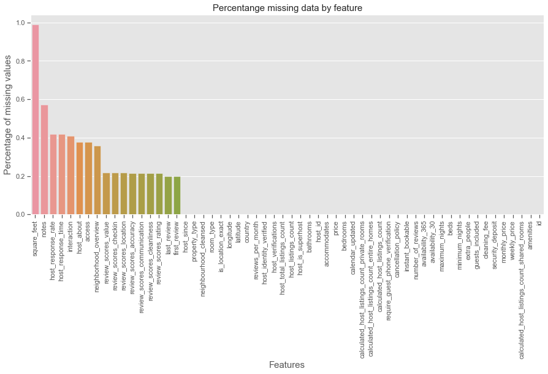

```python
total = listingsDF.isnull().sum().sort_values(ascending=False)
percent = (listingsDF.isnull().sum()/listingsDF.isnull().count()).sort_values(ascending=False)
missing_data = pd.concat([total, percent], axis=1, keys=['Total', 'Percentage'])
f, ax = plt.subplots(figsize=(15, 6))
plt.xticks(rotation='90')
sns.barplot(x=missing_data.index, y=missing_data['Percentage'])
plt.xlabel('Features', fontsize=15)
plt.ylabel('Percentage of missing values', fontsize=15)
plt.title('Percentange missing data by feature', fontsize=15)
missing_data.head()
```

#### 2.2.5 Dropping the columns based on the above barplot

```python
print('The initial shape of the listingsDF before dropping the columns is: ', listingsDF.shape)

#Save the columns that are going to be dropped based on the plot
columns_to_be_dropped = ['square_feet', 'notes', 'access', 'host_about', 'interaction', 'neighborhood_overview']
listingsDF.drop(columns_to_be_dropped, inplace=True, axis=1)
#Square feet is a numerical column, so we are dropping it in the numerical_columns dataframe as well
#numerical_columns.drop('square_feet',1)


print('The shape of the listingsDF after dropping the columns with over 40% missing values is: ', listingsDF.shape)
```

[output not shown]

#### 2.2.6 Keeping the rows that have at least 80% non-null values and dropping all the other rows

```python
#non_na is the number of non null values in listingsDF
non_na = round(listingsDF.shape[1]*0.8)

listingsDF.dropna(thresh=non_na,inplace=True)

print('The shape of the listingsDF after keeping the rows that have at least 80% non-null values ', listingsDF.shape)
```

```
The shape of the listingsDF after keeping the rows that have at least 80% non-null values  (36185, 52)
```

#### 2.2.7 Fill the null values of the host_response_time with 'other', create a new categorical type

```python
listingsDF['host_response_time'].fillna('other', inplace = True)
```

#### 2.2.8 Change the type of the 'host_response_rate' column to categorical and change null values to 'unspecified' category

```python
print("Null values:", listingsDF.host_response_rate.isna().sum())
```

```
Null values: 11467
```

```python
# Use 4 bins for the column host_response_rate column
listingsDF.host_response_rate = pd.cut(listingsDF.host_response_rate, bins=[0, 50, 90, 99, 100], labels=['< 50', '50 to 89', '90 to 99', '100'], include_lowest=True)

# Convert numerical to string, so that I can use the new category that I want to create at the next step
listingsDF.host_response_rate = listingsDF.host_response_rate.astype('str')

# Replace null values with 'unspecified'
listingsDF.host_response_rate.replace('nan', 'unspecified', inplace=True)

# Category counts
listingsDF.host_response_rate.value_counts()
```

```
100            17220
unspecified    11467
50 to 89        3556
90 to 99        2725
< 50            1217
Name: host_response_rate, dtype: int64
```

We spotted that if the 'first_review' of a variable is missing, then many variables dedicated to the reviews are going to be missing as well. Thus, we drop missing values from the column 'first_review'.

```python
listingsDF = listingsDF[np.isfinite(listingsDF['first_review'])]
```

#### 2.2.9 Drop the rest of the rows which contain null values

```python
listingsDF = listingsDF.dropna()
```

```python
listingsDF.info()
```

```
<class 'pandas.core.frame.DataFrame'>
Int64Index: 33350 entries, 0 to 42635
Data columns (total 52 columns):
id                                              33350 non-null int64
host_id                                         33350 non-null int64
host_since                                      33350 non-null datetime64[ns]
host_response_time                              33350 non-null object
host_response_rate                              33350 non-null object
host_is_superhost                               33350 non-null float64
host_listings_count                             33350 non-null float64
host_total_listings_count                       33350 non-null float64
host_verifications                              33350 non-null object
host_identity_verified                          33350 non-null float64
neighbourhood_cleansed                          33350 non-null object
country                                         33350 non-null object
latitude                                        33350 non-null float64
longitude                                       33350 non-null float64
is_location_exact                               33350 non-null int64
property_type                                   33350 non-null object
room_type                                       33350 non-null object
accommodates                                    33350 non-null int64
bathrooms                                       33350 non-null float64
bedrooms                                        33350 non-null float64
beds                                            33350 non-null float64
amenities                                       33350 non-null object
price                                           33350 non-null int64
weekly_price                                    33350 non-null int64
monthly_price                                   33350 non-null int64
security_deposit                                33350 non-null int64
cleaning_fee                                    33350 non-null int64
guests_included                                 33350 non-null int64
extra_people                                    33350 non-null int64
minimum_nights                                  33350 non-null int64
maximum_nights                                  33350 non-null int64
calendar_updated                                33350 non-null object
availability_30                                 33350 non-null int64
availability_365                                33350 non-null int64
number_of_reviews                               33350 non-null int64
first_review                                    33350 non-null datetime64[ns]
last_review                                     33350 non-null datetime64[ns]
review_scores_rating                            33350 non-null float64
review_scores_accuracy                          33350 non-null float64
review_scores_cleanliness                       33350 non-null float64
review_scores_checkin                           33350 non-null float64
review_scores_communication                     33350 non-null float64
review_scores_location                          33350 non-null float64
review_scores_value                             33350 non-null float64
instant_bookable                                33350 non-null int64
cancellation_policy                             33350 non-null object
require_guest_phone_verification                33350 non-null int64
calculated_host_listings_count                  33350 non-null int64
calculated_host_listings_count_entire_homes     33350 non-null int64
calculated_host_listings_count_private_rooms    33350 non-null int64
calculated_host_listings_count_shared_rooms     33350 non-null int64
reviews_per_month                               33350 non-null float64
dtypes: datetime64[ns](3), float64(17), int64(22), object(10)
memory usage: 13.5+ MB
```

Now that we got rid of all the missing values from the dataset, we can apply the Machine Learning Models.

```python
listingsDF.describe()
```

|  | id | host_id | host_is_superhost | host_listings_count | host_total_listings_count | ... | calculated_host_listings_count | calculated_host_listings_count_entire_homes | calculated_host_listings_count_private_rooms | calculated_host_listings_count_shared_rooms | reviews_per_month |
| --- | --- | --- | --- | --- | --- | --- | --- | --- | --- | --- | --- |
| count | 3.335000e+04 | 3.335000e+04 | 33350.000000 | 33350.000000 | 33350.000000 | ... | 33350.000000 | 33350.000000 | 33350.000000 | 33350.000000 | 33350.000000 |
| mean | 1.311895e+07 | 4.320252e+07 | 0.204498 | 18.234903 | 18.234903 | ... | 14.966267 | 12.748516 | 1.771424 | 0.050345 | 0.923465 |
| std | 6.806740e+06 | 4.479339e+07 | 0.403340 | 121.948225 | 121.948225 | ... | 96.124506 | 95.589315 | 7.088671 | 0.720465 | 1.244780 |
| min | 1.155100e+04 | 4.775000e+03 | 0.000000 | 0.000000 | 0.000000 | ... | 1.000000 | 0.000000 | 0.000000 | 0.000000 | 0.010000 |
| 25% | 7.345444e+06 | 7.795511e+06 | 0.000000 | 1.000000 | 1.000000 | ... | 1.000000 | 0.000000 | 0.000000 | 0.000000 | 0.150000 |
| 50% | 1.423642e+07 | 2.672700e+07 | 0.000000 | 1.000000 | 1.000000 | ... | 1.000000 | 1.000000 | 1.000000 | 0.000000 | 0.480000 |
| 75% | 1.916967e+07 | 6.385796e+07 | 0.000000 | 3.000000 | 3.000000 | ... | 3.000000 | 1.000000 | 1.000000 | 0.000000 | 1.200000 |
| max | 2.299864e+07 | 2.262977e+08 | 1.000000 | 1406.000000 | 1406.000000 | ... | 1130.000000 | 1127.000000 | 135.000000 | 18.000000 | 48.210000 |

8 rows × 39 columns

```python
#Save listingsDF to csv file for later use
listingsDF.to_csv('listingsDF_edited.csv')
```

# 3. Exploratory Data Analysis (EDA)

### 3.1. Identification and removal of univariate outliers based on price

#### 3.1.1 Boxplot of 'price column' from listingsDF

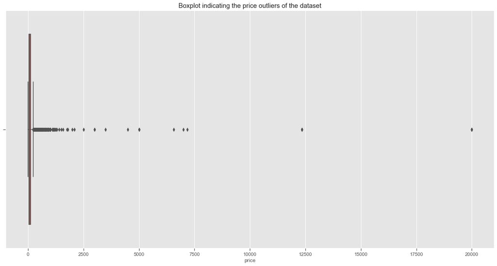

```python
plt.figure(figsize=(20,10))
sns.boxplot(x=listingsDF['price'])
plt.title('Boxplot indicating the price outliers of the dataset', fontsize=15)
```

From the boxplot above, we understand that most of the properties are concentrated in low prices. Subsequently, we will further investigate the existance of outliers.

#### 3.1.2 Saving Numeric features

```python
#Save all the numeric attributes of listingsDF to a dataframe called 'listingsDF_numerics'
numerics = ['int16', 'int32', 'int64', 'float16', 'float32', 'float64']

listingsDF_numerics = listingsDF.select_dtypes(include=numerics)
```

#### 3.1.3 Violin plot for outliers

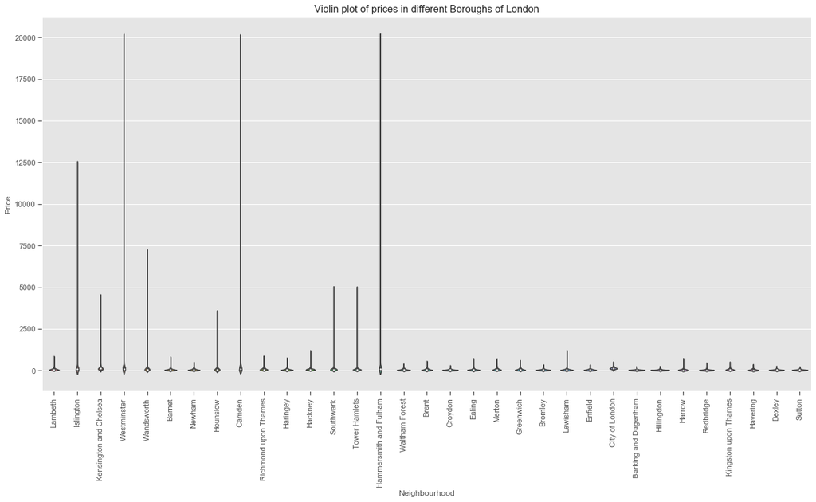

```python
plt.figure(figsize = (20, 10))
sns.violinplot(x = listingsDF['neighbourhood_cleansed'], y = listingsDF['price'], data = listingsDF)
plt.title("Violin plot of prices in different Boroughs of London")
plt.xlabel("Neighbourhood")
plt.ylabel("Price")
plt.xticks(rotation='90')
```

In datasets with many outliers, we opt to use robust statistic techniques , such as the median. In this case Violin plots we used, to point out the probability density of the data at different values, as well as the shape of the distribution.

From the plot we spot the existance of many outliers again.

#### 3.1.4 Scatterplot for Outliers

[figure not shown]

```python
plt.figure(figsize=(20,10))
plt.scatter(listingsDF[listingsDF['price']<2000].neighbourhood_cleansed, listingsDF[listingsDF['price']<2000].price)
plt.title('Review scores rating based on the number of reviews')
plt.xlabel('Neighbourhood')
plt.ylabel('Price')
plt.xticks(rotation=90)
pass
```

We focus on prices under £2000. From the scatterplot above, we can clearly see the existance of univariate outliers in the Price of the properties, based on the Neighbourhood.

#### 3.1.5 Check Outliers Quantiles

```python
#Calculate the quantiles of the properties price and keep the prices which are lower than £450
listingsDF['price'].quantile([0.50, 0.95, 0.99, 0.999])
```

```
0.500      78.000
0.950     250.000
0.990     450.000
0.999    1150.651
Name: price, dtype: float64
```

Based on the quantiles, we keep the prices *under £450.*

#### 3.1.6 Removing outliers

```python
#Removing the Price Outliers by Saving the listings with prices under £450 in a new Dataframe called listingsDF2
listingsDF2 = listingsDF[listingsDF['price']<450]
num_properties_over_450 = listingsDF.shape[0] - listingsDF2.shape[0]
print('The number of the properties that cost more than 450£ is: ', num_properties_over_450)
print('The number of the properties that cost less than 450£ is: ', listingsDF2.shape[0])
```

```
The number of the properties that cost more than 450£ is:  349
The number of the properties that cost less than 450£ is:  33001
```

```python
#Saving some basic statistic of the listingsDF2 dataframe, like mean, max, min, count, etc
stats_clean_price = listingsDF2.describe()
print ('The mean price of the properties in London is: ', stats_clean_price['price']['mean'])
stats_clean_price
```

```
The mean price of the properties in London is:  93.98827308263385
```

|  | id | host_id | host_is_superhost | host_listings_count | host_total_listings_count | ... | calculated_host_listings_count | calculated_host_listings_count_entire_homes | calculated_host_listings_count_private_rooms | calculated_host_listings_count_shared_rooms | reviews_per_month |
| --- | --- | --- | --- | --- | --- | --- | --- | --- | --- | --- | --- |
| count | 3.300100e+04 | 3.300100e+04 | 33001.000000 | 33001.000000 | 33001.000000 | ... | 33001.000000 | 33001.000000 | 33001.000000 | 33001.000000 | 33001.000000 |
| mean | 1.310237e+07 | 4.311942e+07 | 0.204418 | 17.216206 | 17.216206 | ... | 14.334626 | 12.110360 | 1.782007 | 0.050877 | 0.927432 |
| std | 6.804334e+06 | 4.470459e+07 | 0.403282 | 117.636466 | 117.636466 | ... | 93.321736 | 92.768538 | 7.121414 | 0.724246 | 1.249515 |
| min | 1.155100e+04 | 4.775000e+03 | 0.000000 | 0.000000 | 0.000000 | ... | 1.000000 | 0.000000 | 0.000000 | 0.000000 | 0.010000 |
| 25% | 7.336533e+06 | 7.783002e+06 | 0.000000 | 1.000000 | 1.000000 | ... | 1.000000 | 0.000000 | 0.000000 | 0.000000 | 0.150000 |
| 50% | 1.421754e+07 | 2.668119e+07 | 0.000000 | 1.000000 | 1.000000 | ... | 1.000000 | 1.000000 | 1.000000 | 0.000000 | 0.480000 |
| 75% | 1.915446e+07 | 6.368182e+07 | 0.000000 | 3.000000 | 3.000000 | ... | 3.000000 | 1.000000 | 1.000000 | 0.000000 | 1.210000 |
| max | 2.299864e+07 | 2.262977e+08 | 1.000000 | 1406.000000 | 1406.000000 | ... | 1130.000000 | 1127.000000 | 135.000000 | 18.000000 | 48.210000 |

8 rows × 39 columns

#### 3.1.7 Saving numeric columns and scaling them

```python
#Save all the numeric attributes of listingsDF2 to a dataframe called 'listings_DF2_numerics', with prices < 450
numerics = ['int16', 'int32', 'int64', 'float16', 'float32', 'float64']

listingsDF2_numerics = listingsDF2.select_dtypes(include=numerics)
listingsDF2_numerics.info()
```

```
<class 'pandas.core.frame.DataFrame'>
Int64Index: 33001 entries, 0 to 42635
Data columns (total 39 columns):
id                                              33001 non-null int64
host_id                                         33001 non-null int64
host_is_superhost                               33001 non-null float64
host_listings_count                             33001 non-null float64
host_total_listings_count                       33001 non-null float64
host_identity_verified                          33001 non-null float64
latitude                                        33001 non-null float64
longitude                                       33001 non-null float64
is_location_exact                               33001 non-null int64
accommodates                                    33001 non-null int64
bathrooms                                       33001 non-null float64
bedrooms                                        33001 non-null float64
beds                                            33001 non-null float64
price                                           33001 non-null int64
weekly_price                                    33001 non-null int64
monthly_price                                   33001 non-null int64
security_deposit                                33001 non-null int64
cleaning_fee                                    33001 non-null int64
guests_included                                 33001 non-null int64
extra_people                                    33001 non-null int64
minimum_nights                                  33001 non-null int64
maximum_nights                                  33001 non-null int64
availability_30                                 33001 non-null int64
availability_365                                33001 non-null int64
number_of_reviews                               33001 non-null int64
review_scores_rating                            33001 non-null float64
review_scores_accuracy                          33001 non-null float64
review_scores_cleanliness                       33001 non-null float64
review_scores_checkin                           33001 non-null float64
review_scores_communication                     33001 non-null float64
review_scores_location                          33001 non-null float64
review_scores_value                             33001 non-null float64
instant_bookable                                33001 non-null int64
require_guest_phone_verification                33001 non-null int64
calculated_host_listings_count                  33001 non-null int64
calculated_host_listings_count_entire_homes     33001 non-null int64
calculated_host_listings_count_private_rooms    33001 non-null int64
calculated_host_listings_count_shared_rooms     33001 non-null int64
reviews_per_month                               33001 non-null float64
dtypes: float64(17), int64(22)
memory usage: 10.1 MB
```

#### 3.1.8 Boxplot for prices under £450

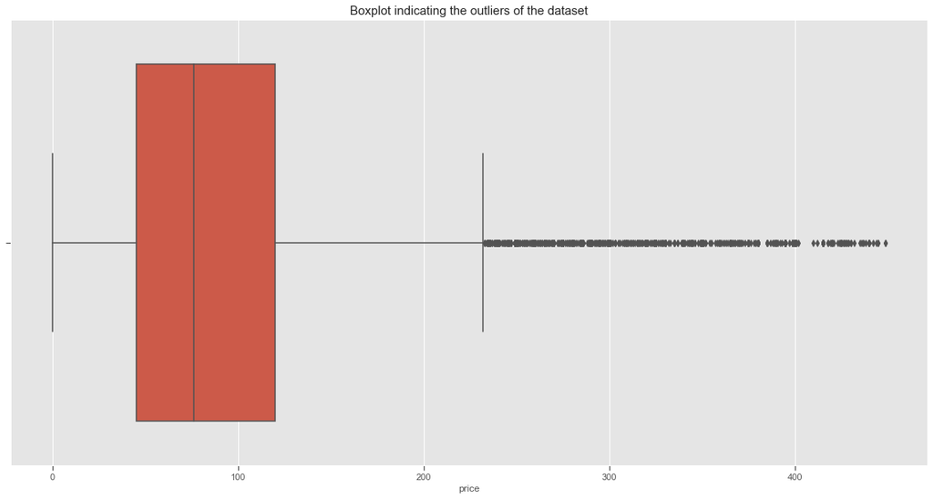

```python
#Taking into consideration the new dataframe with listing prices < 450
plt.figure(figsize=(20,10))
sns.boxplot(x=listingsDF2['price'])
plt.title('Boxplot indicating the outliers of the dataset', fontsize=15)
```

#### 3.1.9. Violinplot for prices under £450

[figure not shown]

```python
plt.figure(figsize = (30, 20))
sns.violinplot(x = listingsDF2['neighbourhood_cleansed'], y = listingsDF2['price'], data = listingsDF2)
plt.title("Box plots of house number of reviews based on price")
plt.xlabel("Neighbourhood")
plt.ylabel("Price")
plt.xticks(rotation='90')
```

We can visually spot a difference in the distribution of the property price per night. Moreover, all the Median values of the prices, which are denoted by the white dots, are concentrated in prices under £200. The highest median prices per night are spotted for the areas of 'City of London', 'Kensington and Chelsea' and 'Westminster'.

We should check the distribution of the continuous variable 'price' (per night), which will be used as target.

### 3.2 How does the Distribution of property prices look like?

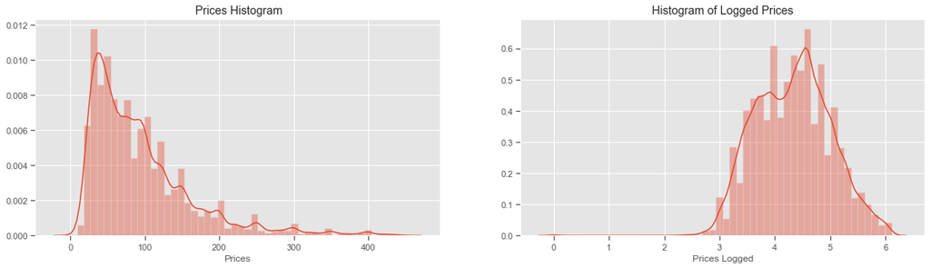

```python
plt.figure(num=2, figsize=(20, 5), linewidth=2)

plt.subplot(1,2,1)
sns.distplot(listingsDF2_numerics.price, kde=True, bins = 50)
plt.xlabel('Prices')
plt.title(' Prices Histogram')

plt.subplot(1,2,2)
sns.distplot(np.log1p(listingsDF2_numerics.price), kde=True, bins = 50)
plt.xlabel('Prices Logged')
plt.title('Histogram of Logged Prices');
```

```python
print( 'Excess kurtosis of normal distribution : {}'.format( kurtosis(listingsDF2_numerics.price) ))
print( 'Skewness of normal distribution : {}'.format( skew(listingsDF2_numerics.price) ))
```

```
Excess kurtosis of normal distribution : 3.9585061528013945
Skewness of normal distribution : 1.779151177653361
```

### 3.3 How does the distribution of the Review Scores Ratings look like?

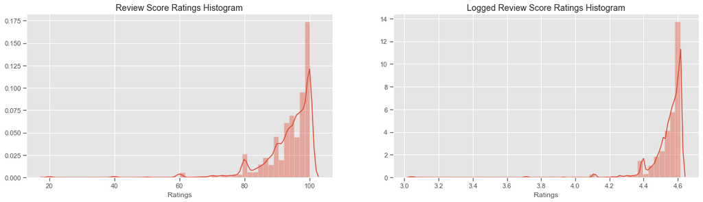

```python
plt.figure(num=2, figsize=(20, 5), linewidth=2)

plt.subplot(1,2,1)
sns.distplot(listingsDF2_numerics['review_scores_rating'], kde=True, bins = 50)
plt.xlabel('Ratings')
plt.title('Review Score Ratings Histogram')

plt.subplot(1,2,2)
sns.distplot(np.log1p(listingsDF2_numerics['review_scores_rating']), kde=True, bins = 50)
plt.xlabel('Ratings')
plt.title('Logged Review Score Ratings Histogram');
```

From the Histograms above we can see that the reviews scores have a negative skewness, as most of the values are concentrated in the 80-100%. The same happens when we have logged values of the reviews.

### 3.4 Mahalanobis Distance for Outlier Identification

We could have used Mahalanobis distance and scoring for outliers identification as an alternative.

```python
#Initialize columns to check for outliers
outliers_columns = ['price', 'review_scores_rating']

mean_value = listingsDF[outliers_columns].mean().values.reshape(1, len(outliers_columns))

# Mahalanobis distance from each row to the mean_value
outliers_scores = cdist(listingsDF[outliers_columns], mean_value, metric='mahalanobis')

#check
outliers_scores
```

```
array([[0.15461516],
       [0.36000993],
       [0.33166377],
       ...,
       [0.84849535],
       [0.80606571],
       [0.0834755 ]])
```

### 3.5 How are the Airbnb properties sparsed in London locationwise?

[figure not shown]

```python
plt.figure(figsize=(20,10))
plt.scatter(listingsDF.longitude, listingsDF.latitude)
plt.title('Airbnb properties of London Mapped')
plt.xlabel('Latitude')
plt.ylabel('Longtitude')
plt.xticks(rotation=90)
pass
```

The density of the Airbnb properties in the central areas and famous tourist attractions of London is higher compared to other Boroughs.

### 3.6 Hosts joining Airbnb from 2009 until Octorer 2019

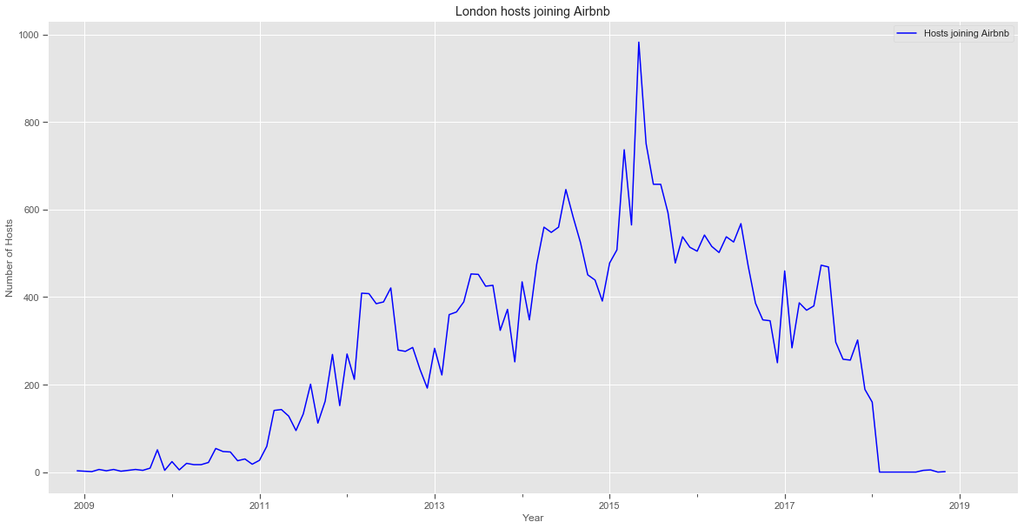

```python
#Plot time series with the hosts joining Airbnb since the month it was created until October 2019
plt.figure(figsize=(20,10))
listingsDF.set_index('host_since').resample('M').size().plot(label='Hosts joining Airbnb', color='blue')
plt.title('London hosts joining Airbnb')
plt.legend()
plt.xlim('2008-08-01', '2019-09-30')
plt.xlabel('Year')
plt.ylabel('Number of Hosts')
plt.show()
```

We observe an upward trend of the graph from 2011 onwards -London Olympics took place in the summer of 2012- . The largest number of hosts in London joined Airbnb in mid 2015, but from that point on we spot a high reduction in this number, until today.

### 3.7 First review of listings submitted through time

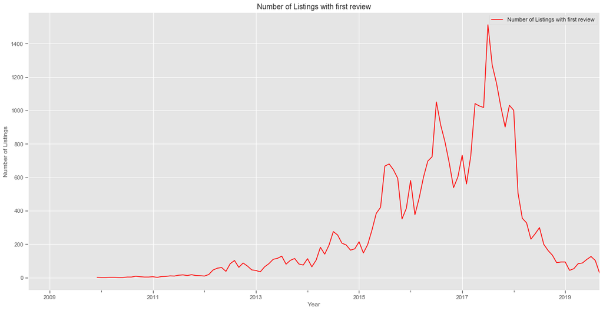

```python
#Plot time series with the hosts joining Airbnb since the month it was created until October 2019
plt.figure(figsize=(20,10))
listingsDF.set_index('first_review').resample('M').size().plot(label='Number of Listings with first review', color='red')
plt.title('Number of Listings with first review')
plt.legend()
plt.xlim('2008-08-01', '2019-09-30')
plt.xlabel('Year')
plt.ylabel('Number of Listings')
plt.show()
```

Although the largest number of hosts joining Airbnb was spotted in 2015, most of the properties got their first review during 2017. After that point, following the previous (blue) graph, the number of listings getting their first review started decreasing a lot, probably as a result of the small number of new porperties joining the platform.

### 3.8 Explore Different Features affecting the price of a property

#### 3.8.1 What are the different types of the Airbnb properties?

```python
labels = listingsDF['property_type'].value_counts().index.tolist()

values = listingsDF['property_type'].value_counts().tolist()

fig = go.Figure(data=[go.Pie(labels=labels, values=values)])

fig.update_layout(
    title="Airbnb Property Types"
)
fig.show()

#Reference link: https://plot.ly/python/pie-charts/
```

[interactive chart not shown]

The majority of the Airbnb properties listed in London are Apartments - 67.9% - , Houses - 20.5% - and 11.6% are included in the category 'Other', which was created as a generalised approach of the problem for visualisation purposes.

#### 3.8.2 What are the different room types?

```python
labels = listingsDF['room_type'].value_counts().index.tolist()

values = listingsDF['room_type'].value_counts().tolist()

fig = go.Figure(data=[go.Pie(labels=labels, values=values)])

fig.update_layout(
    title="Airbnb Room Types"
)
fig.show()

#Reference link: https://plot.ly/python/pie-charts/
```

[interactive chart not shown]

From the second pie plot we can see that 54.5% of the properties listed are Entire Homes or Apartments and the host does not live in the same property when visitors are staying in. At the same time, 44.9% of the listings are Private rooms, indicating that visitors stay in sharing-properties when it comes to short-term bookings. The shared-room listings are spotted in the last position with 0.657%.

#### 3.8.3 How many properties of the 3 different types can we spot in each Borough?

```python
#Create a dataframe with the Boroughs and the property type
property_type_boroughDF = listingsDF[['neighbourhood_cleansed', 'property_type']]

#Group them and convert to dataframe
property_type_boroughDF = pd.DataFrame(property_type_boroughDF.groupby(['neighbourhood_cleansed', 'property_type'], as_index=False).size()).reset_index()

#Chan ge the column names to use them in the bar chart below
property_type_boroughDF.rename(columns = {property_type_boroughDF.columns[2] : 'summary'}, inplace = True)


property_type_boroughDF
```

|  | neighbourhood_cleansed | property_type | summary |
| --- | --- | --- | --- |
| 0 | Barking and Dagenham | Apartment | 33 |
| 1 | Barking and Dagenham | House | 27 |
| 2 | Barking and Dagenham | Other | 7 |
| 3 | Barnet | Apartment | 257 |
| 4 | Barnet | House | 234 |
| ... | ... | ... | ... |
| 94 | Wandsworth | House | 411 |
| 95 | Wandsworth | Other | 229 |
| 96 | Westminster | Apartment | 2767 |
| 97 | Westminster | House | 217 |
| 98 | Westminster | Other | 288 |

99 rows × 3 columns

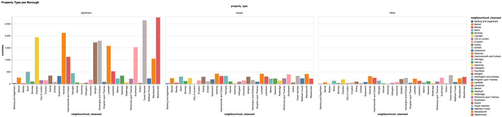

```python
alt.renderers.enable('notebook')
#Use of altair barplot to indicate the number of 3 different types of properties in London Boroughs
alt.Chart(property_type_boroughDF).mark_bar().encode(
    x= ('neighbourhood_cleansed:O'),
    y= alt.Y('summary:Q'),
    color='neighbourhood_cleansed:N',
    column='property_type:N'
).properties(
    title='Property Type per Borough'
)

#Reference Link: https://altair-viz.github.io/gallery/grouped_bar_chart.html
```

Most of the apartments in London are concentrated in Westminster, Tower Hamlets, Hackney, Camden, Kensington and Chelsea, Islington, Southwark and Lambeth.

Houses are mostly spotted in less central boroughs, such as Wandsworth, Hackney and Lambeth.

#### 3.8.4 How many rooms of the 3 different types can we spot, in each Borough?

```python
#Create a dataframe with the Boroughs and the room type
room_type_boroughDF = listingsDF[['neighbourhood_cleansed', 'room_type']]

#Group them and convert to dataframe
room_type_boroughDF = pd.DataFrame(room_type_boroughDF.groupby(['neighbourhood_cleansed', 'room_type'], as_index=False).size()).reset_index()

#Chan ge the column names to use them in the bar chart below
room_type_boroughDF.rename(columns = {room_type_boroughDF.columns[2] : 'summary'}, inplace = True)


room_type_boroughDF
```

|  | neighbourhood_cleansed | room_type | summary |
| --- | --- | --- | --- |
| 0 | Barking and Dagenham | Entire home/apt | 19 |
| 1 | Barking and Dagenham | Private room | 48 |
| 2 | Barnet | Entire home/apt | 219 |
| 3 | Barnet | Private room | 328 |
| 4 | Barnet | Shared room | 2 |
| ... | ... | ... | ... |
| 91 | Wandsworth | Private room | 791 |
| 92 | Wandsworth | Shared room | 3 |
| 93 | Westminster | Entire home/apt | 2288 |
| 94 | Westminster | Private room | 975 |
| 95 | Westminster | Shared room | 9 |

96 rows × 3 columns

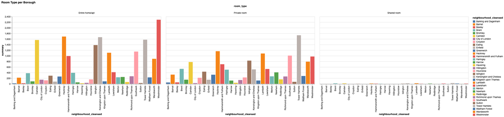

```python
#Use of altair barplot to indicate the number of 3 different types of rooms in London Boroughs
import altair as alt
alt.renderers.enable('notebook')

alt.Chart(room_type_boroughDF).mark_bar().encode(
    x= ('neighbourhood_cleansed:O'),
    y= alt.Y('summary:Q'),
    color='neighbourhood_cleansed:N',
    column='room_type:N'
).properties(
    title='Room Type per Borough'
)

#Reference Link: https://altair-viz.github.io/gallery/grouped_bar_chart.html
```

Most of the Entire Home/apt properties in London exist in the areas of Westminster, Tower Hamlets, Kensington and Chelsea, Hackney, Camden.

Most of the famous Airbnb boroughs, located close to tourist attractions, are concentrated on the Western side of the city, on the North part of Thames River.

### 3.9 How are the Review Scores Rating and the Number of Reviews of the properties correlated?

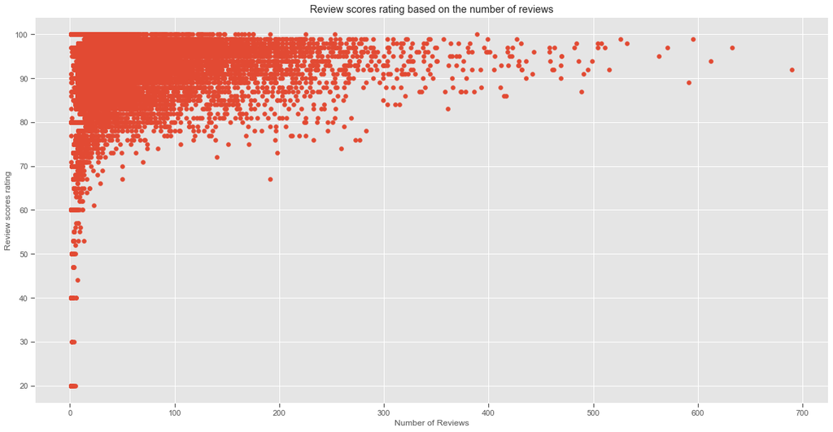

```python
plt.figure(figsize=(20,10))
plt.scatter(listingsDF2.number_of_reviews, listingsDF2.review_scores_rating)
plt.title('Review scores rating based on the number of reviews')
plt.xlabel('Number of Reviews')
plt.ylabel('Review scores rating')
```

Most of the properties reviews are highly-rated.

[figure not shown]

```python
plt.figure(figsize=(20,10))
plt.scatter(listingsDF2.price, listingsDF2.review_scores_rating)
plt.title('Review scores rating based on the number of reviews')
plt.xlabel('Median Prices')
plt.ylabel('Review scores rating')
```

We cannot find a specific relation to the Reviews Scores and the Median Prices. We need to create categories of the scores, to get more insights of the relationship "Reviews Scores Ratings" - "Price".

```python
#Create a copy of the listingsDF2 called reviews
reviews = listingsDF2

#Initialize binning
bins=[0, 50, 90, 99, 100]

#Inititalize binning labels
labels=['< 50', '50 to 89', '90 to 99', '100']

#Apply binning in 'binned_review_scores_rating' column
reviews['binned_review_scores_rating'] = pd.cut(reviews['review_scores_rating'], bins, labels, include_lowest=True)

#Convert column to type String
reviews['binned_review_scores_rating'] = reviews['binned_review_scores_rating'].astype('str')

#Convert it to dataframe
reviews = reviews['binned_review_scores_rating'].value_counts().reset_index()

#check
reviews
```

|  | index | binned_review_scores_rating |
| --- | --- | --- |
| 0 | (90.0, 99.0] | 17114 |
| 1 | (50.0, 90.0] | 8312 |
| 2 | (99.0, 100.0] | 7393 |
| 3 | (-0.001, 50.0] | 182 |

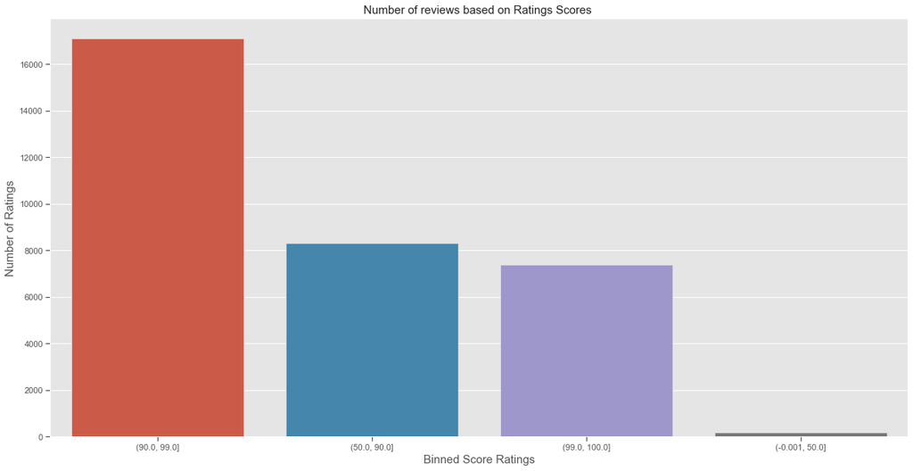

```python
plt.figure(figsize=(20,10))
sns.barplot(x=reviews['index'], y=reviews['binned_review_scores_rating'])
plt.xlabel('Binned Score Ratings', fontsize=15)
plt.ylabel('Number of Ratings', fontsize=15)
plt.title('Number of reviews based on Ratings Scores ', fontsize=15)
```

Indeed, from the barplot we observe that the majority of the property reviews are 90-99%, which declares *a trend of visitors leaving good reviews in general.*

### 3.10 What is the Median, the Mean and the distribution of the prices per Borough? What do we understand from that?

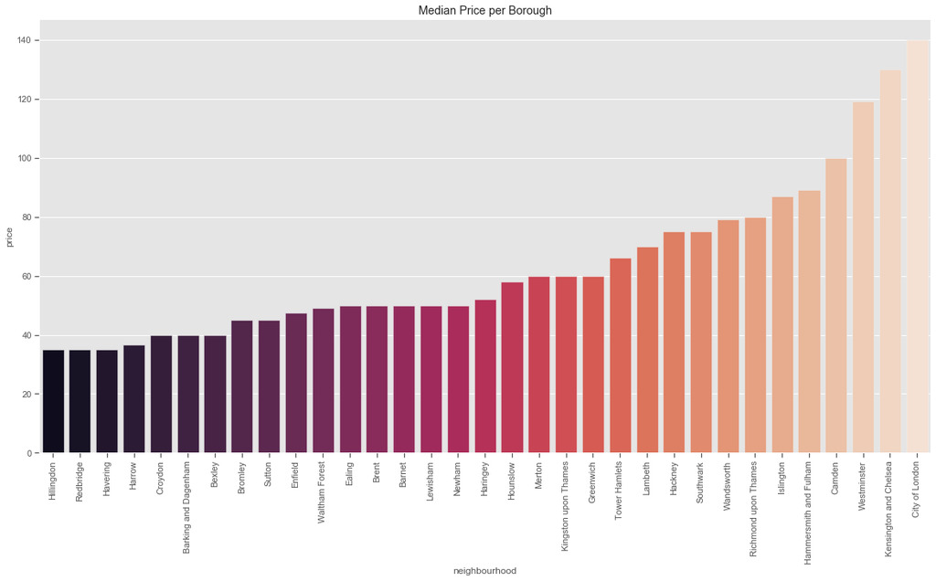

```python
#Calculate the median of the price of each neighbourhood in London, sort the dataframe, then plot it
medianListingsDF = listingsDF.groupby('neighbourhood_cleansed').median()[['price']].reset_index()
medianListingsDF = medianListingsDF.sort_values('price')

#Barplot
plt.figure(figsize=(20,10))
plt.title('Median Price per Borough')
sns.barplot(data = medianListingsDF, x = 'neighbourhood_cleansed', y = 'price', palette="rocket")
plt.xlabel('neighbourhood')
plt.ylabel('price')
plt.xticks(rotation=90)
```

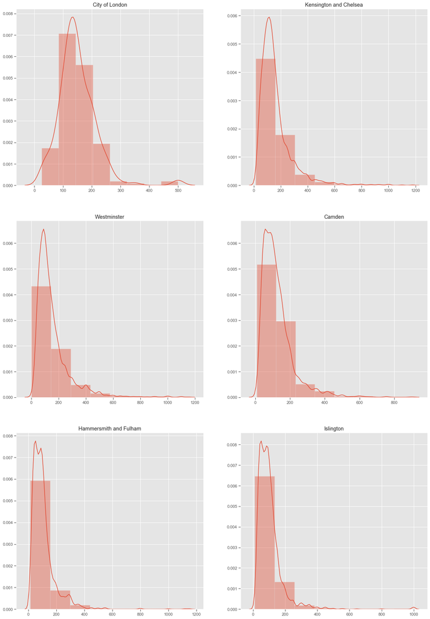

```python
plt.figure(figsize=(20,30))

plt.subplot(3,2,1)
temp = listingsDF[listingsDF['neighbourhood_cleansed'] == 'City of London'][['price']]
sns.distplot(temp[temp['price'] < 1200], bins=8)
plt.title('City of London')



plt.subplot(3,2,2)
temp = listingsDF[listingsDF['neighbourhood_cleansed'] == 'Kensington and Chelsea'][['price']]
sns.distplot(temp[temp['price'] < 1200], bins=8)
plt.title('Kensington and Chelsea')

plt.subplot(3,2,3)
temp = listingsDF[listingsDF['neighbourhood_cleansed'] == 'Westminster'][['price']]
sns.distplot(temp[temp['price'] < 1200], bins=8)
plt.title('Westminster')

plt.subplot(3,2,4)
temp = listingsDF[listingsDF['neighbourhood_cleansed'] == 'Camden'][['price']]
sns.distplot(temp[temp['price'] < 1200], bins=8)
plt.title('Camden')

plt.subplot(3,2,5)
temp = listingsDF[listingsDF['neighbourhood_cleansed'] == 'Hammersmith and Fulham'][['price']]
sns.distplot(temp[temp['price'] < 1200], bins=8)
plt.title('Hammersmith and Fulham')

plt.subplot(3,2,6)
temp = listingsDF[listingsDF['neighbourhood_cleansed'] == 'Islington'][['price']]
sns.distplot(temp[temp['price'] < 1200], bins=8)
plt.title('Islington')
```

The price per night distributions of the six highest median-price-valued Boroughs have a positive skeweness.

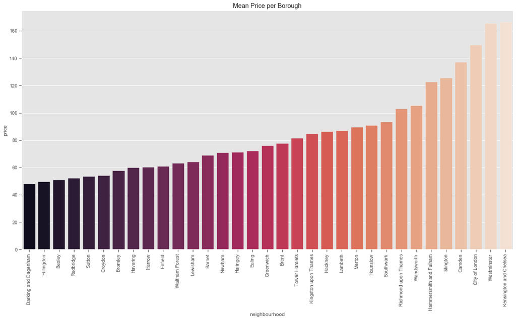

```python
#Calculate the mean of the price, of each neighbourhood in London and sort the dataframe
meanListingsDF = listingsDF.groupby('neighbourhood_cleansed').mean()[['price']].reset_index()
meanListingsDF = meanListingsDF.sort_values('price')

#Barplot
plt.figure(figsize=(20,10))
plt.title('Mean Price per Borough')
sns.barplot(data = meanListingsDF, x = 'neighbourhood_cleansed', y = 'price', palette="rocket")
plt.xlabel('neighbourhood')
plt.ylabel('price')
plt.xticks(rotation=90)
```

This is an interesting observation. The mean property price of 'Kensington and Chelsea' and 'Westminster' are higher than the one in 'City of London'. Nevertheless, the median price per night of 'City of London' is higher. This is a result of the many price outliers that are concentrated in our dataset.

### 3.11 What are the Maximum and Minimum prices of properties per Borough?

```python
#Maximum prices per Borough before removing the outliers
maxGroupedListingsDF1 = pd.DataFrame(listingsDF.groupby(['neighbourhood_cleansed'], sort=False)['price'].max().reset_index())
#Sorting based on the price column
maxGroupedListingsDF1 = maxGroupedListingsDF1.sort_values('price')
maxGroupedListingsDF1
```

|  | neighbourhood_cleansed | price |
| --- | --- | --- |
| 32 | Sutton | 220 |
| 25 | Barking and Dagenham | 240 |
| 26 | Hillingdon | 250 |
| 31 | Bexley | 250 |
| 17 | Croydon | 300 |
| 30 | Havering | 340 |
| 23 | Enfield | 340 |
| 21 | Bromley | 349 |
| 15 | Waltham Forest | 400 |
| 28 | Redbridge | 450 |
| 29 | Kingston upon Thames | 490 |
| 6 | Newham | 500 |
| 24 | City of London | 500 |
| 16 | Brent | 550 |
| 20 | Greenwich | 599 |
| 19 | Merton | 689 |
| 27 | Harrow | 700 |
| 18 | Ealing | 711 |
| 10 | Haringey | 750 |
| 5 | Barnet | 799 |
| 0 | Lambeth | 846 |
| 9 | Richmond upon Thames | 850 |
| 11 | Hackney | 1198 |
| 22 | Lewisham | 1200 |
| 7 | Hounslow | 3500 |
| 2 | Kensington and Chelsea | 4500 |
| 12 | Southwark | 5000 |
| 13 | Tower Hamlets | 5000 |
| 4 | Wandsworth | 7175 |
| 1 | Islington | 12345 |
| 14 | Hammersmith and Fulham | 20000 |
| 3 | Westminster | 20000 |
| 8 | Camden | 20000 |

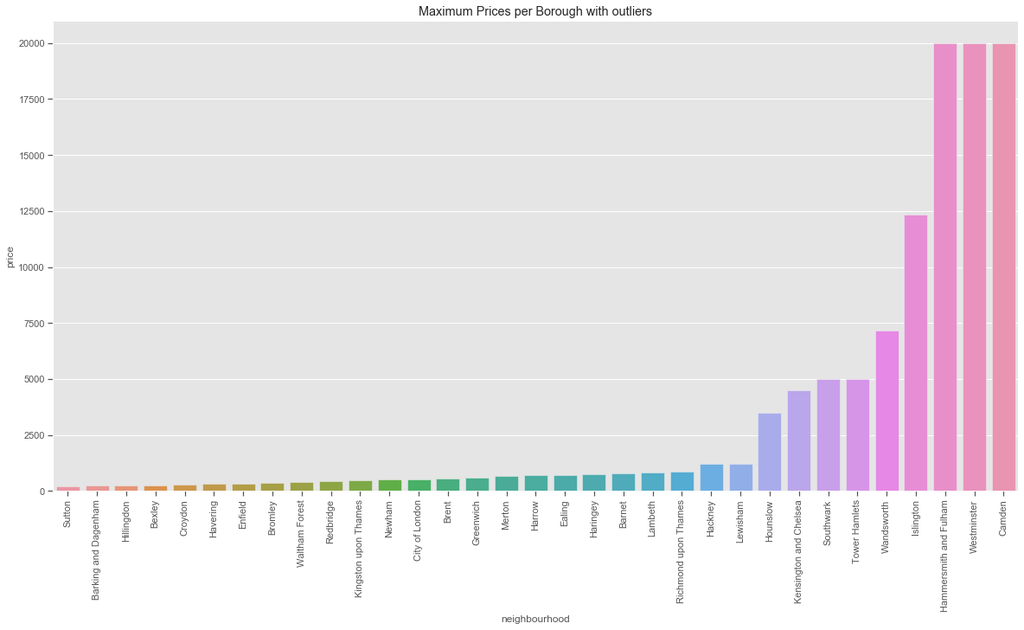

```python
#Plot figure of the initial dataset to showcase the Maximum prices per borough with extreme outliers
plt.figure(figsize=(20,10))
plt.title('Maximum Prices per Borough with outliers')
sns.barplot(data = maxGroupedListingsDF1, x = 'neighbourhood_cleansed', y = 'price')
plt.xlabel('neighbourhood')
plt.ylabel('price')
plt.xticks(rotation=90)
```

```python
maxGroupedListingsDF2 = pd.DataFrame(listingsDF2.groupby(['neighbourhood_cleansed'], sort=False)['price'].max().reset_index())
minGroupedListingsDF2 = pd.DataFrame(listingsDF2.groupby(['neighbourhood_cleansed'], sort=False)['price'].min().reset_index())

print('maxGroupedListingsDF2')
print(maxGroupedListingsDF2)
print()
print('minGroupedListingsDF2')
print(minGroupedListingsDF2)
```

```
maxGroupedListingsDF2
    neighbourhood_cleansed  price
0                  Lambeth    425
1                Islington    440
2   Kensington and Chelsea    445
3              Westminster    449
4               Wandsworth    442
5                   Barnet    400
6                   Newham    400
7                 Hounslow    420
8                   Camden    449
9     Richmond upon Thames    410
10                Haringey    400
11                 Hackney    401
12               Southwark    425
```

[output cut: 56 more lines]

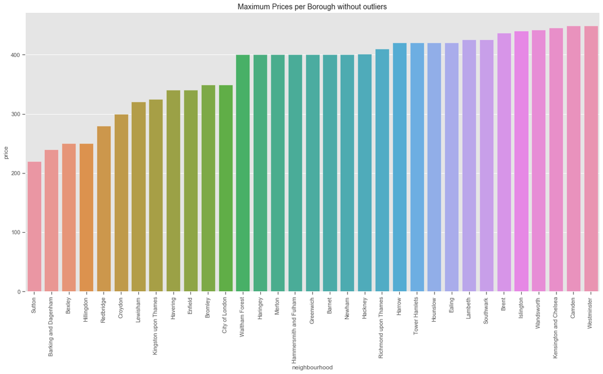

```python
#Barplot based on the Maximum properties prices of each Borough
maxGroupedListingsDF2 = maxGroupedListingsDF2.sort_values('price')

plt.figure(figsize=(20,10))
plt.title('Maximum Prices per Borough without outliers')
sns.barplot(data = maxGroupedListingsDF2, x = 'neighbourhood_cleansed', y = 'price')
plt.xlabel('neighbourhood')
plt.ylabel('price')
plt.xticks(rotation=90)
```

After removing the prices over £450 we observe that the allocation of the boroughs changes. Westminster, Camden, Kensington and Chelsea own the most expensive properties.

### 3.12 How are the Median prices and Review Scores Ratings correlated per Borough?

```python
#Calculate the median of the review scores rating per Borough
medianReviewsListingsDF = listingsDF.groupby('neighbourhood_cleansed').median()[['review_scores_rating']].reset_index()
#sort the medianReviewsListingsDF
sortedMedianReviewsListingsDF = medianReviewsListingsDF.sort_values(by = 'review_scores_rating')
```

```python
#Calculating the median listing
medianListingsDF = pd.concat([medianListingsDF, medianReviewsListingsDF['review_scores_rating']], axis=1, join='outer', ignore_index=False)
medianListingsDF = medianListingsDF.sort_values(by ='price' )
```

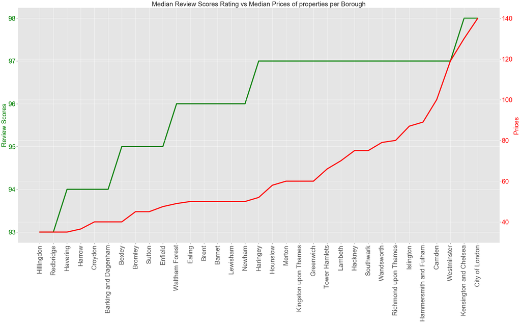

```python
#Using the same x-axes neighbourhood and y1-axis = Review Scores and y2-axis = Prices
labels = medianListingsDF['neighbourhood_cleansed']

fig, ax1 = plt.subplots(figsize=(40, 20))

ax1.plot(medianListingsDF['neighbourhood_cleansed'], sortedMedianReviewsListingsDF['review_scores_rating'], lw=5, color="green")

#ax1 axis is the median Review Scores
ax1.set_ylabel(r"Review Scores", fontsize=30, color="green")
for label in ax1.get_yticklabels():
    label.set_color("green")
    label.set_size(30)

#ax2 axis is the median property price
ax2 = ax1.twinx()
ax2.plot(medianListingsDF['neighbourhood_cleansed'], medianListingsDF['price'], lw=5, color="red")
ax2.set_ylabel(r"Prices", fontsize=30, color="red")
for label in ax2.get_yticklabels():
    label.set_color("red")
    label.set_size(30)

ax1.set_title('Median Review Scores Rating vs Median Prices of properties per Borough', size = 30)


ax1.set_xticklabels(medianListingsDF['neighbourhood_cleansed'], rotation=90, size = 30)

pass
```

We observe that the Median Prices in each Borough vary from less than £40, up to £140 per night.

Moreover, we understand that reviewers tend to leave good review ratings, with the median Review Scores varying between 93%, up to 98%, as we previously also spotted from the barplot 'Number of Reviews based on Ratings scores'.

#### 3.13 What is the monthly number of reviews per property, in each Borough?

```python
#group dataset based  on the neighbourhood_cleansed column
mean_monthly_reviews = listingsDF.groupby('neighbourhood_cleansed').mean()[['reviews_per_month']].reset_index()

#calculate the mean of the monthly reviews for each Borough
mean_monthly_reviews = mean_monthly_reviews.sort_values(by = 'reviews_per_month')
```

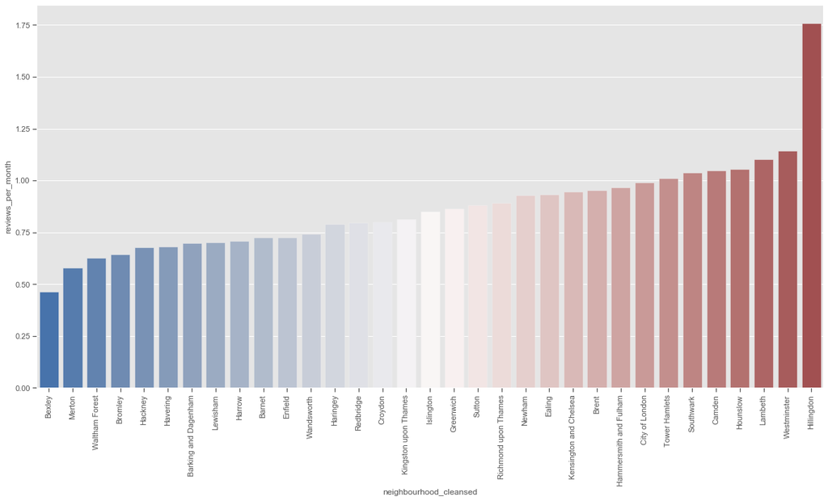

```python
#Plot based on the mean values
plt.figure(figsize=(20,10))
sns.barplot(data = mean_monthly_reviews, x = 'neighbourhood_cleansed', y = 'reviews_per_month', palette="vlag")
plt.xticks(rotation=90)
```

The number of monthly reviews per each property could potentially be a success performance indicator. We observe that Hillington, Westminster, Lambeth, Hownslow, Camden, Southwark and Tower Hamlets tend to have at least one monthly review.

### 4. Feature Engineering

### 4. 1 Pearson's correlation Heatmap for highly correlated features with the 'price'

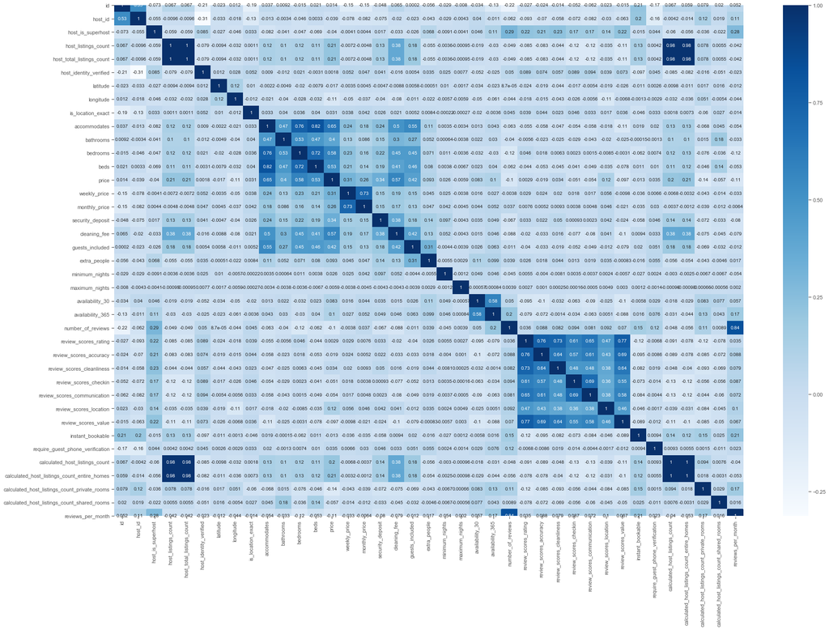

```python
#We are only using the numeric columns of the reduced dataset
plt.figure(figsize=(30,20))
#calculate the correlation
correlation = listingsDF2_numerics.corr()
#plot
sns.heatmap(correlation, annot=True, cmap='Blues')
plt.show()
```

```python
#Correlation with target variable in absolute value
corr_target = abs(correlation["price"])
#Selecting highly correlated features
relevant_features = corr_target[corr_target>0.2]
relevant_features
```

```
price                                          1.000000
host_listings_count                            0.206590
accommodates                                   0.654064
bathrooms                                      0.395641
bedrooms                                       0.580589
beds                                           0.530991
weekly_price                                   0.312630
security_deposit                               0.342532
cleaning_fee                                   0.569478
guests_included                                0.422954
calculated_host_listings_count                 0.201982
calculated_host_listings_count_entire_homes    0.211184
Name: price, dtype: float64
```

For the Modelling Part I will keep only the highly correlated features with the target: 'price'.

However, we have to test if those features are correlated between them, so we are going to produce another correlation heatmap only with those features.

```python
#Save the above outcome in a new dataFrame called 'listingsDF2_modelling'
listingsDF2_modelling = listingsDF2_numerics[['price','host_listings_count', 'accommodates', 'bathrooms', 'bedrooms', 'beds', 'weekly_price', 'security_deposit', 'cleaning_fee', 'guests_included', 'calculated_host_listings_count', 'calculated_host_listings_count_entire_homes']]
```

```python
#Scaling the values of the dataframe for better accuracy purposes in the Models
scaler = MinMaxScaler(feature_range=(0, 1), copy=True)
scaler.fit(listingsDF2_modelling)
scaled_listingsDF2_modelling = pd.DataFrame(scaler.transform(listingsDF2_modelling), index=listingsDF2_modelling.index, columns=listingsDF2_modelling.columns)

scaled_listingsDF2_modelling
```

|  | price | host_listings_count | accommodates | bathrooms | bedrooms | ... | security_deposit | cleaning_fee | guests_included | calculated_host_listings_count | calculated_host_listings_count_entire_homes |
| --- | --- | --- | --- | --- | --- | --- | --- | --- | --- | --- | --- |
| 0 | 0.195991 | 0.002134 | 0.200000 | 0.105263 | 0.125 | ... | 0.098790 | 0.055147 | 0.066667 | 0.000886 | 0.001775 |
| 1 | 0.144766 | 0.002845 | 0.066667 | 0.105263 | 0.125 | ... | 0.024697 | 0.027574 | 0.000000 | 0.001771 | 0.000887 |
| 2 | 0.222717 | 0.000711 | 0.066667 | 0.105263 | 0.125 | ... | 0.037046 | 0.091912 | 0.066667 | 0.000000 | 0.000887 |
| 3 | 0.668151 | 0.012802 | 0.333333 | 0.210526 | 0.375 | ... | 0.086441 | 0.119485 | 0.200000 | 0.012400 | 0.013310 |
| 4 | 0.389755 | 0.000000 | 0.066667 | 0.157895 | 0.125 | ... | 0.061744 | 0.128676 | 0.066667 | 0.000000 | 0.000887 |
| ... | ... | ... | ... | ... | ... | ... | ... | ... | ... | ... | ... |
| 42629 | 0.100223 | 0.002134 | 0.066667 | 0.105263 | 0.125 | ... | 0.049395 | 0.055147 | 0.000000 | 0.000886 | 0.000887 |
| 42630 | 0.149220 | 0.003556 | 0.066667 | 0.105263 | 0.125 | ... | 0.000000 | 0.055147 | 0.000000 | 0.005314 | 0.005324 |
| 42631 | 0.066815 | 0.000711 | 0.000000 | 0.105263 | 0.125 | ... | 0.024697 | 0.018382 | 0.000000 | 0.000000 | 0.000000 |
| 42634 | 0.218263 | 0.000711 | 0.066667 | 0.105263 | 0.125 | ... | 0.061744 | 0.055147 | 0.000000 | 0.000000 | 0.000000 |
| 42635 | 0.182628 | 0.000711 | 0.200000 | 0.105263 | 0.250 | ... | 0.037046 | 0.055147 | 0.200000 | 0.000000 | 0.000887 |

33001 rows × 12 columns

One of the assumptions of linear regression is that the independent variables need to be uncorrelated with each other. If these variables are correlated with each other, then we need to keep only one of them and drop the rest. Link: https://towardsdatascience.com/feature-selection-with-pandas-e3690ad8504b

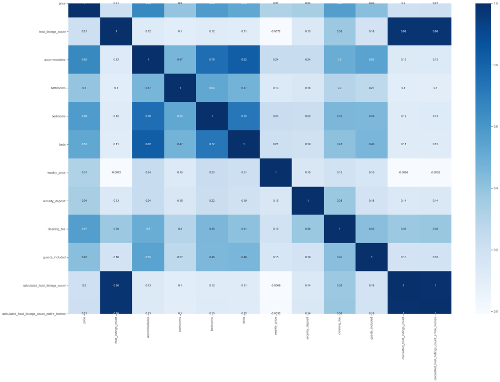

```python
plt.figure(figsize=(30,20))
correlation = scaled_listingsDF2_modelling.corr()
sns.heatmap(correlation, annot=True, cmap='Blues')
plt.show()
```

Based on the *Filter Method* we should remove one or more of the features, that are highly correlated between them.

However, we are using *Lasso Modelling* for feature selection, for better accuracy results.

### 4.2 Splitting the dataset in train and test sets

```python
#X training test of the reduced dataset after the first correlation map, use in the Baseline Model
X = scaled_listingsDF2_modelling.drop(["price"], axis = 1)   #Feature Matrix
y = scaled_listingsDF2_modelling['price'] #Target Variable
X_train, X_test, y_train, y_test = train_test_split(X, y, test_size = 0.3, random_state=9)
```

```python
y1 = pd.DataFrame(y)
```

### 4.3 Feature Selection through Lasso Modelling

```python
reg = LassoCV()
reg.fit(X, y)
print("Best alpha using built-in LassoCV: %f" % reg.alpha_)
print("Best score using built-in LassoCV: %f" %reg.score(X,y))
print()

coef = pd.Series(reg.coef_, index = X.columns)
print("Lasso picked " + str(sum(coef >= 0.1)) + " variables and eliminated " +  str(sum(coef < 0.1)) + " variables")
```

```
Best alpha using built-in LassoCV: 0.000025
Best score using built-in LassoCV: 0.548715

Lasso picked 7 variables and eliminated 4 variables
```

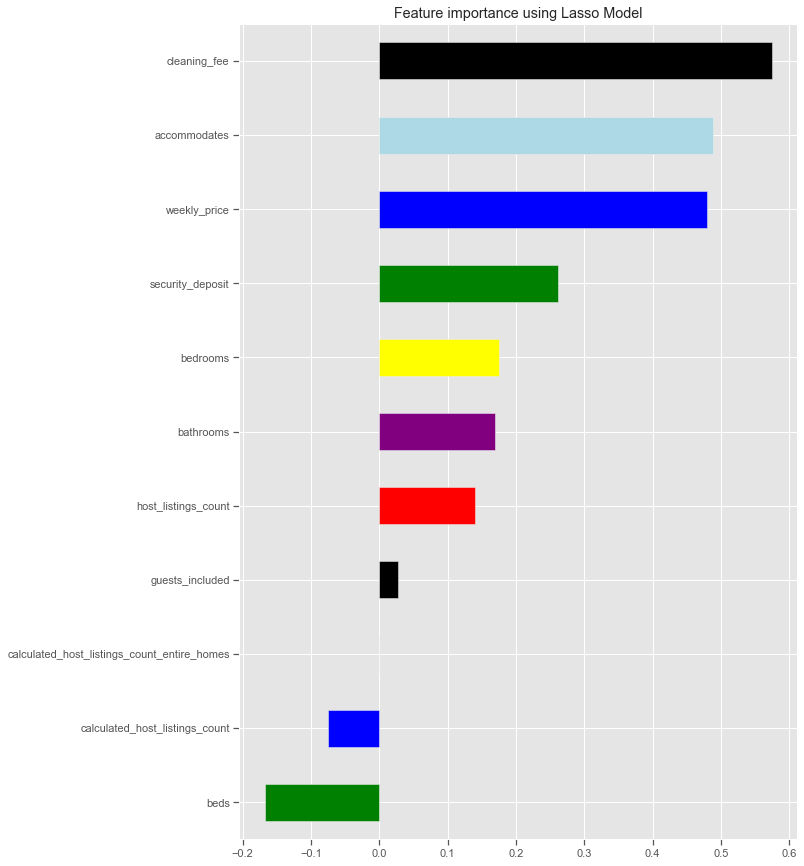

```python
imp_coef = coef.sort_values()
import matplotlib
matplotlib.rcParams['figure.figsize'] = (10.0, 15.0)
imp_coef.plot(kind = "barh", color=["green", "blue", "lightblue", "black", "red", "purple", "yellow"])
plt.title("Feature importance using Lasso Model")
```

From the Lasso modelling applied we will keep the 7 important features:

- 'cleaning fee'
- 'accomodates'
- 'weekly_price'
- 'security_deposit'
- 'bedrooms'
- 'bathrooms'
- 'host_listings_count'

### 4.4 Final DataFrame ready-to-be-used for Machine Learning Models

```python
#Save the above in a new dataFrame called 'scaled_listingsDF2_modelling_final'
scaled_listingsDF2_modelling_final = scaled_listingsDF2_modelling[['price', 'cleaning_fee', 'weekly_price', 'accommodates', 'bathrooms', 'host_listings_count', 'bedrooms', 'security_deposit']]

scaled_listingsDF2_modelling_final
```

|  | price | cleaning_fee | weekly_price | accommodates | bathrooms | host_listings_count | bedrooms | security_deposit |
| --- | --- | --- | --- | --- | --- | --- | --- | --- |
| 0 | 0.195991 | 0.055147 | 0.161161 | 0.200000 | 0.105263 | 0.002134 | 0.125 | 0.098790 |
| 1 | 0.144766 | 0.027574 | 0.083083 | 0.066667 | 0.105263 | 0.002845 | 0.125 | 0.024697 |
| 2 | 0.222717 | 0.091912 | 0.149900 | 0.066667 | 0.105263 | 0.000711 | 0.125 | 0.037046 |
| 3 | 0.668151 | 0.119485 | 0.344595 | 0.333333 | 0.210526 | 0.012802 | 0.375 | 0.086441 |
| 4 | 0.389755 | 0.128676 | 0.262513 | 0.066667 | 0.157895 | 0.000000 | 0.125 | 0.061744 |
| ... | ... | ... | ... | ... | ... | ... | ... | ... |
| 42629 | 0.100223 | 0.055147 | 0.112362 | 0.066667 | 0.105263 | 0.002134 | 0.125 | 0.049395 |
| 42630 | 0.149220 | 0.055147 | 0.112362 | 0.066667 | 0.105263 | 0.003556 | 0.125 | 0.000000 |
| 42631 | 0.066815 | 0.018382 | 0.112362 | 0.000000 | 0.105263 | 0.000711 | 0.125 | 0.024697 |
| 42634 | 0.218263 | 0.055147 | 0.112362 | 0.066667 | 0.105263 | 0.000711 | 0.125 | 0.061744 |
| 42635 | 0.182628 | 0.055147 | 0.112362 | 0.200000 | 0.105263 | 0.000711 | 0.250 | 0.037046 |

33001 rows × 8 columns

### 4.5 Create new X2 and y2

```python
X2 = scaled_listingsDF2_modelling_final.drop(["price"], axis = 1)   #Feature Matrix
y2 = scaled_listingsDF2_modelling_final['price'] #Target Variable
X2_train, X2_test, y2_train, y2_test = train_test_split(X2, y2, test_size = 0.3, random_state=9)
```

# 5. Machine Learning Modelling

### 5.1 Train a Baseline Model as a comparison meter

```python
X_Baseline_train, X_Baseline_test, y_Baseline_train, y_Baseline_test = train_test_split(X, y, test_size=0.3, random_state=100)

#Call the RF regressor with the X,y that were based on the dataset
rfr_baseline = RandomForestRegressor()
rfr_baseline.fit(X_Baseline_train, y_Baseline_train)

predict_baseline = rfr_baseline.predict(X_Baseline_test)
print("The r2 score for Random Forest on CV data is: ", r2_score(y_Baseline_test,predict_baseline))
```

```
The r2 score for Random Forest on CV data is:  0.6539156495088738
```

```python
test_set_rmse_baseline = (np.sqrt(mean_squared_error(y2_test, predict_baseline)))
print('The test set rmse baseline is: ', test_set_rmse_baseline)
```

```
The test set rmse baseline is:  0.20414471822677485
```

### 5.2 Multiple Linear Regression

```python
lin_reg_mod = LinearRegression()
lin_reg_mod.fit(X2_train, y2_train)
pred = lin_reg_mod.predict(X2_test)
test_set_rmse = (np.sqrt(mean_squared_error(y2_test, pred)))
test_set_r2 = r2_score(y2_test, pred)
print('R squared Error = ', test_set_r2)
print('RMSE = ', test_set_rmse)

# Reference: https://stackabuse.com/multiple-linear-regression-with-python/
```

```
R squared Error =  0.5454059867839838
RMSE =  0.10277154023425858
```

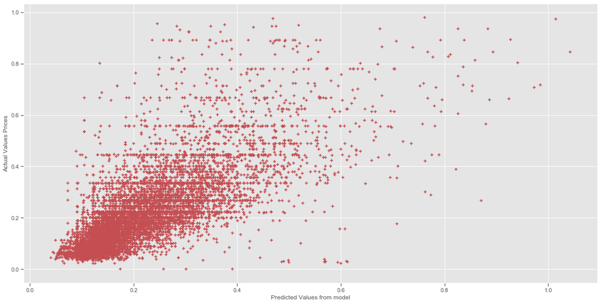

```python
#Plot for multiple Linear Regression
plt.figure(figsize=(20,10))
plt.scatter(pred, y2_test, s=30, c='r', marker='+', zorder=10)
plt.xlabel("Predicted Values from model")
plt.ylabel("Actual Values Prices")
plt.show()
```